# Tarea 6: regularización ridge

En este ejemplo trabajaremos con un [ejemplo de Kaggle](https://www.kaggle.com/c/house-prices-advanced-regression-techniques), en donde queremos predecir el precio listado de una casa dependiendo de varias características.

El diccionario de datos está en el archivo *data_description.txt*

```r
library(tidyverse)
library(glmnet)
datos <- read_csv("./tarea_6_datos/data_train.csv", na= "") %>%
    select(-GarageYrBlt, -LotFrontage, -MasVnrArea, -GarageYrBlt, -MoSold, -PoolQC)
datos$MSSubClass <- factor(datos$MSSubClass)
```

### Preprocesamiento

Necesitamos hacer varios pasos de limpieza y preprocesamiento de datos. Aquí solo haremos una limpieza y transformación parcial para propósitos de nuestro ejemplo.

En primer lugar, nota que muchas de estas variables son categóricas. En los casos donde hay datos no disponibles (NA), estas se cuentan como una categoría más, por ejemplo:

```r
table(datos$Alley)
```

```
Grvl   NA Pave
  50 1369   41
```

En este caso, la categoría NA indica que la casa no tiene acceso por callejón. Igual que en el ejemplo del Titanic, convertimos estas variables con *dummy coding*, o *one hot encoding*.

Podemos usar la función *model.matrix* para hacer este preprocesamiento:

```r
x_datos <- model.matrix(SalePrice ~ ., datos %>% select(-Id))
x_datos <- x_datos[, -1] # quitamos columna de unos
y <- datos$SalePrice
```

Por ejemplo, la variable categórica *Alley* (con 3 niveles) corresponde ahora a dos columnas de variables binarias:

```r
x_datos[c(20,21,22,31), c('AlleyNA','AlleyPave')]
```

```
   AlleyNA AlleyPave
20       1         0
21       1         0
22       0         0
31       0         1
```

que puedes comparar con la variable original

```r
datos[c(20,21,22,31), "Alley"]
```

| Alley |
| --- |
| NA |
| NA |
| Grvl |
| Pave |

Otro ejemplo es la variable *MSZoning*, cuyas categorías son:

```r
table(datos$MSZoning)
```

```
C (all)      FV      RH      RL      RM
     10      65      16    1151     218
```

y corresponde a las nuevas variables

```r
x_datos[1:10, 15:18]
```

```
   MSZoningFV MSZoningRH MSZoningRL MSZoningRM
1           0          0          1          0
2           0          0          1          0
3           0          0          1          0
4           0          0          1          0
5           0          0          1          0
6           0          0          1          0
7           0          0          1          0
8           0          0          1          0
9           0          0          0          1
10          0          0          1          0
```

Aquí mostramos las variables que usaremos para nuestros modelos:

```r
colnames(x_datos)
```

```
  [1] "MSSubClass30"         "MSSubClass40"         "MSSubClass45"         "MSSubClass50"
  [5] "MSSubClass60"         "MSSubClass70"         "MSSubClass75"         "MSSubClass80"
  [9] "MSSubClass85"         "MSSubClass90"         "MSSubClass120"        "MSSubClass160"
 [13] "MSSubClass180"        "MSSubClass190"        "MSZoningFV"           "MSZoningRH"
 [17] "MSZoningRL"           "MSZoningRM"           "LotArea"              "StreetPave"
 [21] "AlleyNA"              "AlleyPave"            "LotShapeIR2"          "LotShapeIR3"
 [25] "LotShapeReg"          "LandContourHLS"       "LandContourLow"       "LandContourLvl"
 [29] "UtilitiesNoSeWa"      "LotConfigCulDSac"     "LotConfigFR2"         "LotConfigFR3"
 [33] "LotConfigInside"      "LandSlopeMod"         "LandSlopeSev"         "NeighborhoodBlueste"
 [37] "NeighborhoodBrDale"   "NeighborhoodBrkSide"  "NeighborhoodClearCr"  "NeighborhoodCollgCr"
 [41] "NeighborhoodCrawfor"  "NeighborhoodEdwards"  "NeighborhoodGilbert"  "NeighborhoodIDOTRR"
 [45] "NeighborhoodMeadowV"  "NeighborhoodMitchel"  "NeighborhoodNAmes"    "NeighborhoodNoRidge"
 [49] "NeighborhoodNPkVill"  "NeighborhoodNridgHt"  "NeighborhoodNWAmes"   "NeighborhoodOldTown"
 [53] "NeighborhoodSawyer"   "NeighborhoodSawyerW"  "NeighborhoodSomerst"  "NeighborhoodStoneBr"
 [57] "NeighborhoodSWISU"    "NeighborhoodTimber"   "NeighborhoodVeenker"  "Condition1Feedr"
```

[output cut: 52 more lines]

Finalmente, la variable que queremos predecir es *SalePrice*:

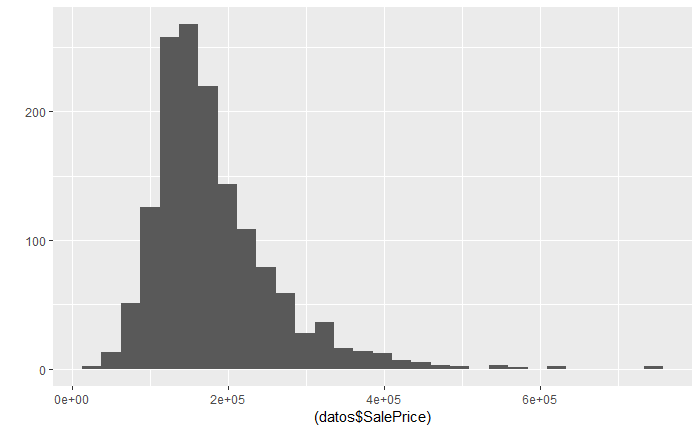

```r
qplot((datos$SalePrice))
```

**Nota: veremos más adelante más pasos de preprocesamiento para mejorar considerablemente el modelo que obtenemos abajo.**

### Regresión ridge

Separamos un conjunto de entrenamiento y uno de prueba (1/2 aproximadamente)

```r
set.seed(9911)
indices_entrena <- sample(1:nrow(x_datos), 700)
x_ent <- x_datos[indices_entrena, -1] # primera columna es de 1's, la quitamos
y_ent <- y[indices_entrena] / 1000 # miles de dólares
x_pr <- x_datos[-indices_entrena, -1]
y_pr <- y[-indices_entrena] / 1000 #miles de dólares
```

1. Utiliza la función glmnet para ajustar modelos lineales para valores de regularización. Utiliza la siguiente sucesión de valores $\lambda$ de regularización ridge:

```r
lambda <- exp(seq(-10, 10, 1))
lambda
```

```
 [1] 4.539993e-05 1.234098e-04 3.354626e-04 9.118820e-04 2.478752e-03 6.737947e-03 1.831564e-02
 [8] 4.978707e-02 1.353353e-01 3.678794e-01 1.000000e+00 2.718282e+00 7.389056e+00 2.008554e+01
[15] 5.459815e+01 1.484132e+02 4.034288e+02 1.096633e+03 2.980958e+03 8.103084e+03 2.202647e+04
```

```r
# completa los parámetros que faltan para ajustar los modelos:
mod_ridge <- glmnet(y = y_ent, x = x_ent , alpha = 0, family = "gaussian",
                lambda = lambda)
```

Grafica la traza de los coeficientes:

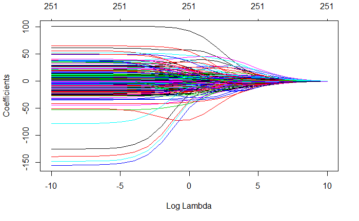

```r
plot(mod_ridge, xvar= "lambda")
```

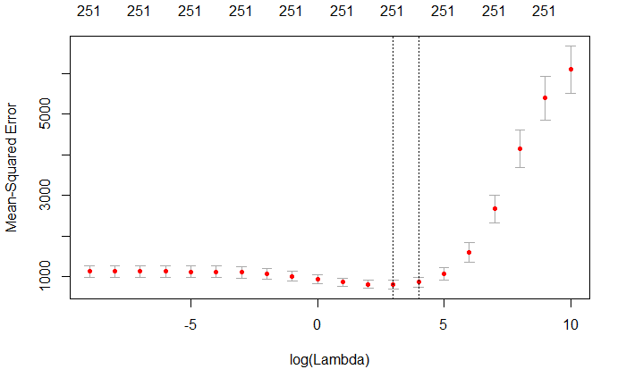

```r
# completa los parámetros que faltan:
cv_mod_1 <- cv.glmnet(y = y_ent, x = x_ent, alpha = 0, family = "gaussian",
                      lambda = lambda, nfolds = 100)
plot(cv_mod_1)
```

```r
cv_mod_1$lambda.min
```

```
[1] 20.08554
```

```r
log(cv_mod_1$lambda.min)
```

```
[1] 3
```

```r
cv_mod_1$lambda.1se
```

```
[1] 54.59815
```

```r
log(cv_mod_1$lambda.1se)
```

```
[1] 4
```

```r
lambda
```

```
 [1] 4.539993e-05 1.234098e-04 3.354626e-04 9.118820e-04 2.478752e-03 6.737947e-03 1.831564e-02
 [8] 4.978707e-02 1.353353e-01 3.678794e-01 1.000000e+00 2.718282e+00 7.389056e+00 2.008554e+01
[15] 5.459815e+01 1.484132e+02 4.034288e+02 1.096633e+03 2.980958e+03 8.103084e+03 2.202647e+04
```

¿Qué valores de la regularización dan los errores más bajos (según la estimación de validación cruzada?)

3. Selecciona un modelo con baja regularización, con el valor óptimo según validación cruzada, y otro con mucha regularización (utiliza las lambdas mostradas abajo). Evalúa el error de predicción (raíz de error cuadrático media) según la muestra de prueba que separamos arriba:

```r
# rellena tres valores, uno con muy baja regularización , uno con regularización
#óptima según validación cruzada, y otro con demasiada regularización:
lambda_pred <- c(lambda[1] , lambda[14],lambda[21] )
lambda_pred
```

```
[1] 4.539993e-05 2.008554e+01 2.202647e+04
```

Calcula errores de prueba

```r
preds_1 <- predict(mod_ridge, newx = x_pr, s = lambda_pred[1])
preds_2 <- predict(mod_ridge, newx = x_pr, s = lambda_pred[2])
preds_3 <- predict(mod_ridge, newx = x_pr, s = lambda_pred[3])
sqrt(mean((preds_1 - y_pr)^2))
```

```
[1] 41.21686
```

```r
sqrt(mean((preds_2 - y_pr)^2))
```

```
[1] 36.18995
```

```r
sqrt(mean((preds_3 - y_pr)^2))
```

```
[1] 74.67852
```

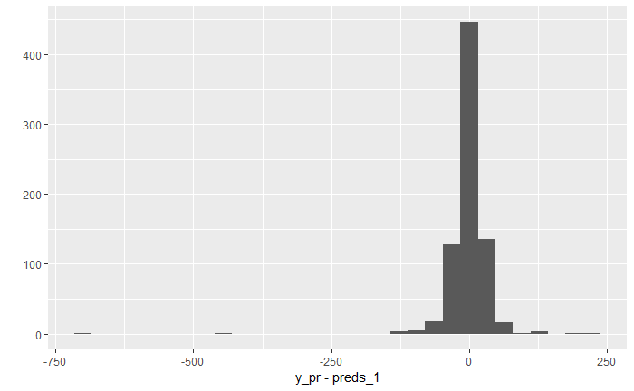

```r
qplot(y_pr - preds_1)
```

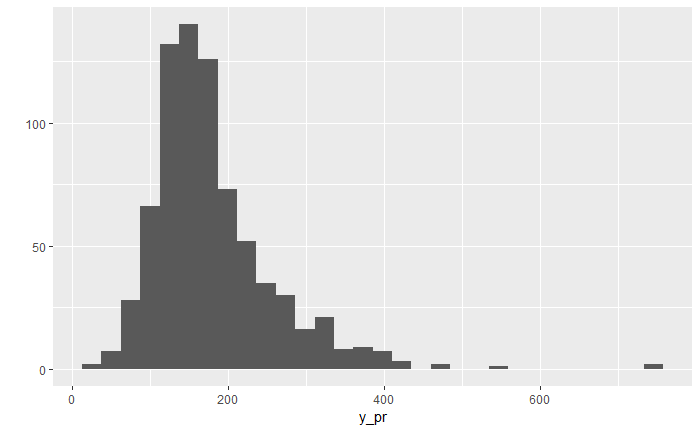

```r
qplot(y_pr)
```

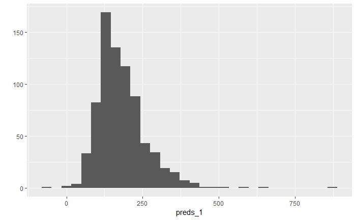

```r
qplot(preds_1)
```

4. Compara los coeficientes del modelo menos regularizado con el de regularización óptima

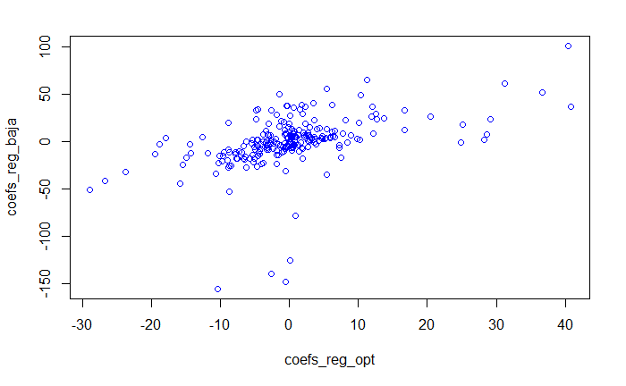

```r
coefs_reg_baja <- predict(mod_ridge,
                          s = lambda_pred[1], type= "coefficients")
coefs_reg_baja <- coefs_reg_baja[-1,1] # tomamos la primera columna y quitamos intercept
# rellena aquí
coefs_reg_opt <- predict(mod_ridge,
                         s = lambda_pred[2], type = "coefficients")
coefs_reg_opt <- coefs_reg_opt[-1,1]

# ahora grafica estos coeficientes en una gráfica x-y:
plot(x = coefs_reg_opt, y= coefs_reg_baja, type = "p", col = "blue")
```

Por ejemplo, compara los coeficientes relacionados con el garage (tipo, terminados, Calidad, Condición, coches y área):

```r
nombres <- names(coefs_reg_baja)
#str_detect(nombres, "Garage")
coef_garage_baja <- coefs_reg_baja[str_detect(nombres, "Garage")]
coef_garage_baja
```

```
 GarageTypeAttchd GarageTypeBasment GarageTypeBuiltIn GarageTypeCarPort  GarageTypeDetchd
      21.24896876       40.79019651       29.94498859       49.91936118       21.44514445
     GarageTypeNA    GarageFinishNA   GarageFinishRFn   GarageFinishUnf        GarageCars
      -5.80134652       -2.36802984       -0.52328638        6.14203771        3.76889437
       GarageArea      GarageQualFa      GarageQualGd      GarageQualNA      GarageQualPo
       0.02424743     -155.57634386     -148.33127869       -3.06087570     -125.60618178
     GarageQualTA      GarageCondFa      GarageCondGd      GarageCondNA      GarageCondPo
    -139.37714948       18.90792107       28.96223486      -78.70272545        1.80192796
     GarageCondTA
      15.13592088
```

- ¿Qué efecto puede tener esta variable en tus predicciones? Considera que el tamaño de los coeficientes está en miles de dólares, Si no tiene algún tipo de garage, tiene un impacto negativo para el precio

Garage Quality - No tienen sentido, GarageQualGd tiene coeficiente más negativo que GarageQualNA o GarageQualPo Garage Condition - Los coeficientes tienen sentido

- ¿Cuál es el valor mediano de las casas en el conjunto de entrenamiento (y)? ¿Los efectos del inciso anterior te parecen razonables?

```r
mean(y_ent)
```

```
[1] 183.3911
```

```r
coef_neighborhood_baja <- coefs_reg_baja[str_detect(nombres, "Neighborhood")]
coef_neighborhood_baja
max(coef_neighborhood_baja)
min(coef_neighborhood_baja)
```

[output not shown]

Repite para regularización óptima según validación cruzada:

```r
# calcula para los coeficientes del modelo más regularizado
coef_garage_opt <- coefs_reg_opt[str_detect(nombres, "Garage")]
coef_garage_opt
```

```
 GarageTypeAttchd GarageTypeBasment GarageTypeBuiltIn GarageTypeCarPort  GarageTypeDetchd
      -0.78930137        3.50213541       12.55401685       -1.41474531       -1.17099538
     GarageTypeNA    GarageFinishNA   GarageFinishRFn   GarageFinishUnf        GarageCars
       0.54143947        0.40821875       -3.42375026        0.22565270        5.23678591
       GarageArea      GarageQualFa      GarageQualGd      GarageQualNA      GarageQualPo
       0.02446150      -10.38174172       -0.51798200        0.67002108        0.06108298
     GarageQualTA      GarageCondFa      GarageCondGd      GarageCondNA      GarageCondPo
      -2.67174662       -0.01802216       -1.80195503        0.93576449       -4.66634123
     GarageCondTA
      -0.17737488
```

- ¿Qué efecto puede tener esta variable en tus predicciones? Considera que el tamaño de los coeficientes está en miles de dólares?

Para el tipo de garage, el coeficiente mayor es GarageTypeBuiltIn, mientras que en el ejemplo anterior era GarageTypeCarPort

Garafe quality sigue sin tener sentido, o ser coherente

- ¿Cuál es el valor mediano de las casas en el conjunto de entrenamiento (y)? ¿Los efectos del inciso anterior te parecen razonables?